# Regrese

Klíčové pojmy:

- závislá/nezávislá proměnná
- rovnice přímky
- konstanta a směrnice
- metoda nejmenších čtverců
- interval spolehlivosti pro směrnici
- předpoklady lineární regrese

Regresní analýza se používá k popsání vztahu mezi dvěma kardinálními proměnnými. S konceptem závislé a nezávislé proměnné jsme se seznámili při analýze rozptylu. Závislá proměnná je taková proměnná, kterou se snažíme vysvětlit. Nezávislá proměnné je taková, kterou používáme k vysvětlení závislé proměnné. Pojďme si tuto analýzu ukázat na příkladu vztahu mezi výškou a váhou.

```r
d <- read.csv("https://raw.githubusercontent.com/schubertjan/cuni/master/stats/data/vyska_vaha.csv")
head(d)
```

```
##   vyska vaha pohlavi
## 1 174.0 65.6       0
## 2    NA   NA       0
## 3 193.5 80.7       0
## 4 186.5 72.6       0
## 5    NA 78.8       0
## 6 181.5 74.8       0
```

```r
# nejprve se musime rozhodnout, co udelat s chybejicicmi hodnotami
# vyradime vsechny, kde je vaha nebo vyska NA. To se rovna cor(d$vyska, d$vaha, use="complete.obs")
d <- d[!is.na(d$vyska) & !is.na(d$vaha), ]
# kontrola
sum(is.na(d))
```

```
## [1] 0
```

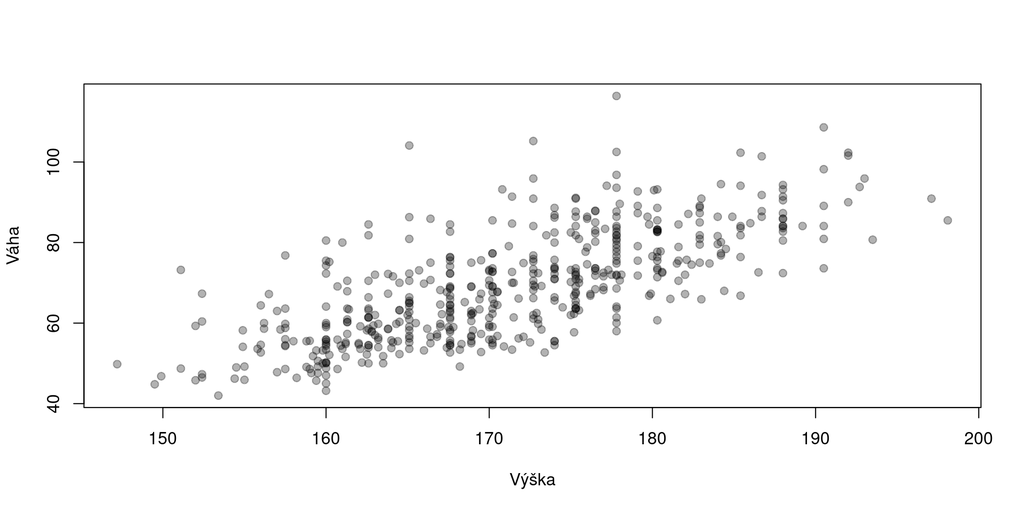

```r
# zobrazime vztah
plot(d$vyska, d$vaha,
     xlab = "Výška",
     ylab = "Váha",
     pch = 19,
     col = adjustcolor("black", alpha.f = 0.3))
```

Při regresní analýze protneme přímku mezi body obou (nebo více) proměnných. Přímka je popsána dvěma parametry - konstantou a směrnicí. Konstanta ( $\alpha$ nebo také $\beta_0$) vyjadřuje hodnotu, v které přímka protne osu $y$, pokud je $x=0$. Směrnice ($\beta$) vyjadřuje, o kolik se změní přímka, pokud $x$ vzroste o jednotku. Tedy, $y_i=\alpha+\beta X_i$.

Tuto přímku potřebujeme body protnout tak, abychom minimalizovali chybu přímky $e$, respektive její sumu čtverců $\sum_{i=1}^n e_i^2$. Parametry takové přímky bychom mohli vypočítat jako $\beta=(X^TX)^{-1}X^TY$. V R bychom tuto přímku mohli vypočítat pomocí funkce `lm`.

Pojďme si tuto chybu ukázat na příkladě.

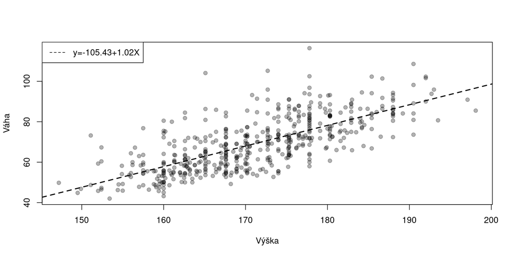

```r
m <- lm(d$vaha ~ d$vyska)

plot(d$vyska, d$vaha,
     xlab = "Výška",
     ylab = "Váha",
     pch = 19,
     col = adjustcolor("black", alpha.f = 0.3))
abline(m, lty = 2, lwd = 2)
legend("topleft",
       legend = paste0("y=", round(coef(m)[1], 2), "+", round(coef(m)[2], 2), "X"),
       lty= 2,
       col = "black")
```

Pokud bychom chtěli parametry vypočítat pomocí vzorce nahoře.

```r
# pripravime si y a X. Pridame sloupec jednicek, protoze pocitame s konstantou
y <- d$vaha
X <- cbind(rep(1, nrow(d)), d$vyska)
# reseni
params <- solve(t(X) %*% X)%*%t(X)%*%y

print(paste0("Konstanta: ", params[1,1]))
```

```
## [1] "Konstanta: -105.434143743362"
```

```r
print(paste0("Směrnice: ", params[2,1]))
```

```
## [1] "Směrnice: 1.02018394941171"
```

Směrnice má hodnotu zhruba o 1.02, tedy pokud vzroste výška o 1cm, v průměru vzroste váha o 1.02kg. Hodnota konstanty -105.4 znamená, že pokud bude výška 0cm bude (v průměru) váha -105.4kg. To je samozřejmě nesmysl, ale v našem malém modelu, kde existují pouze lineární vztahy, je toto správný výpočet.

Skoro nikdy nebudou ležet všechny body přesně na přímce. To, jak dobře přímka vystihuje lineární vztah dvou proměnných můžeme měřit pomocí míry celkového rozptylu, který můžeme vysvětlit naší přímkou $R^2 = 1-\frac{SS_{e}}{SS_{total}}$. Sumu čtverců jsme si ukazovali při analýze rozptylu. Tento obrazek vystihuje vzorec $R^2$ graficky. Červená suma čtverců vyjadřuje $SS_{total}$ a modrá $SS_{e}$. Toto číslo můžeme také interpretovat jako % celkové variability $y$, které je možné vysvětlit našim modelem.

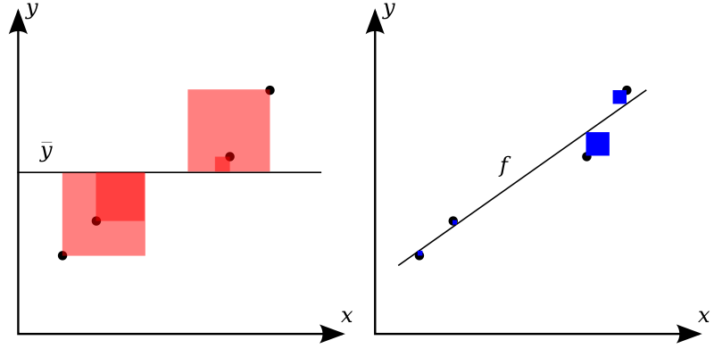

Většinou náš model (naše přímka) nevystihne všechnu variabilitu v závislé proměnné $y$. To, co nedokážeme vysvětlit našim modelem označujeme jako $e$. Naši regresní přímku tedy zapíšeme jako $y_i=\alpha+\beta X_i + e_i$. Stejně jako u ostatních statistik, pokud počítáme regresní přímku na výběru, existuje určitá míra nejistoty ohledně populačním parametrů (populační konstanty a směrnice, tedy takové přímky, jakou bychom vypočítali, kdybychom měli data za všechna pozorování, ne pouze za výběr). A stejně jako u ostatních statistik, můžeme u parametrů přímky vypočítat standardní chybu. Tyto standarní chyby využívají rozptyl chyby $s{_e} = \frac{\sum_{i=1}^n e_i^2}{(n-p)}$, kde $n$ je počet pozorování a $p$ je počet parametrů. Standardní chybu směrnice vypočítáme jako $s_{\beta_1} = s_{e}\sqrt\frac{1}{\sum_{i=1}^n (x_i - \bar{x})^2}$ a standardní chybu konstanty jako $s_{\alpha} = s_{e}\sqrt{\frac{1}{n}+\frac{\bar{x}^2}{\sum_{i=1}^n (x_i - \bar{x})^2}}$. V R můžeme tyto hodnoty získat pomocí funkce `summary`, kterou použijeme na objektu, do kterého jsme uložili výsledky našeho modelu. Při dodržení předpokladů regresní analýzy mají testovací statistiky parametrů t rozdělení s $n-p$ stupni volnosti.

```r
s <- summary(m)
s_a <- s$coefficients[, 1]
s_b <- s$coefficients[, 2]

# nebo rucne pomoci vzorce
n <- nrow(d)
p <- 2
s_e <- sqrt(sum(m$residuals^2) / (n-p))
s_b <- s_e*sqrt(1/(sum((d$vyska - mean(d$vyska))^2)))
s_a <- s_e*sqrt((1/n) + mean(d$vyska)^2/(sum((d$vyska - mean(d$vyska))^2)))
```

Ukažme si příklad testování směrnice. Nulovou hypotézu můžeme formulovat například jako $H_0: \beta = 0$ a tedy $H_1 \ne 0$. Stejně ale můžeme zvolit pravo/levo stranný test a jinou než 0 hodnotu nulové hypotézy. Například $H_0 \le4$a $H_1>4$. Testovací statistiku vypočítáme jako $t = \frac{\hat{\beta}- H_0}{s_{\beta_1}}$.

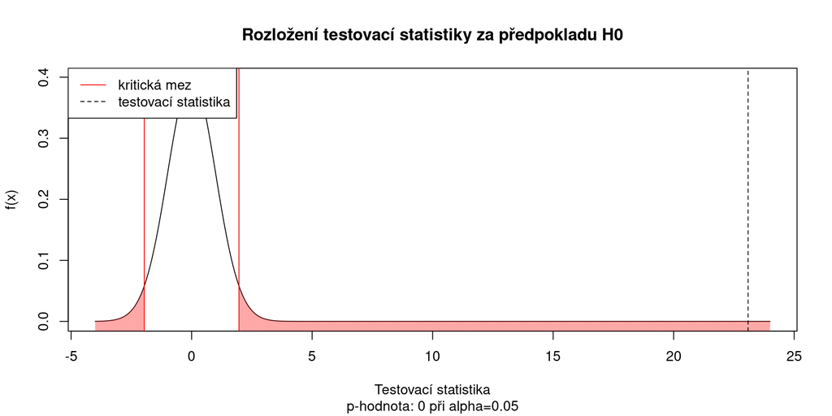

```r
# H0: b = 0
# H1: b != 0
t <- coef(m)[2] / s_b
s_v <- n-p
alpha <- 0.05
kriticka_mez <- qt(c(alpha/2, 1-alpha/2), df = s_v)
p <- (1-pt(abs(t), df = s_v))*2

x <- seq(-4,24,by=0.001)
pdf <- dt(x, df = s_v)

plot(x, pdf,
     xlab = "Testovací statistika", ylab = "f(x)",
     main = "Rozložení testovací statistiky za předpokladu H0",
     sub = paste0("p-hodnota: ", p, " při alpha=", alpha),
     type = "l")
abline(v = kriticka_mez[1], col = "red")
abline(v = kriticka_mez[2], col = "red")
# oblast zamitnuti H0
for(i in c(1:length(x))) {
  if(x[i] > kriticka_mez[2] | x[i] < kriticka_mez[1]) {
    lines(c(x[i], x[i]), c(-1, pdf[i]),
          col = adjustcolor("red", alpha.f = 0.01))
  }
}
abline(v = t, lty = 2)
legend("topleft",
       c("kritická mez", "testovací statistika"),
       col = c("red", "black"),
       lty = c(1,2))
```

Stejně tak bychom mohli vypočítat interval spolehlivosti pro $\hat{\beta}$.

```r
is <- coef(m)[2] + kriticka_mez * s_b
print(paste0("Interval spolehlivosti pro beta je: ", paste0(round(is, 2), collapse = " až ")))
```

```
## [1] "Interval spolehlivosti pro beta je: 0.93 až 1.11"
```

Stejně tak bychom tento výpočet mohli udělat pomocí funkce `confint`.

```r
confint(m)
```

```
##                    2.5 %     97.5 %
## (Intercept) -120.3104850 -90.557803
## d$vyska        0.9333711   1.106997
```

Předpoklady lineární regrese při použití metody nejmenších čtverců:

1. $e$ jsou normálně rozloženy s průměrem 0 a směrodatnou odchylkou rovnou $s_{e}$.
2. rozptyl chyb $e$ je homogenní po celé délce přímky
3. jednotlivé body $(x_i, y_i)$ jsou mezi sebou nezávislé

Bod 1. můžeme ověřit pomocí histogramu $e$ a výpočtu průměru a směrodatné odchylky $e$ a jejich porovnání s teoretickou hodnotou.

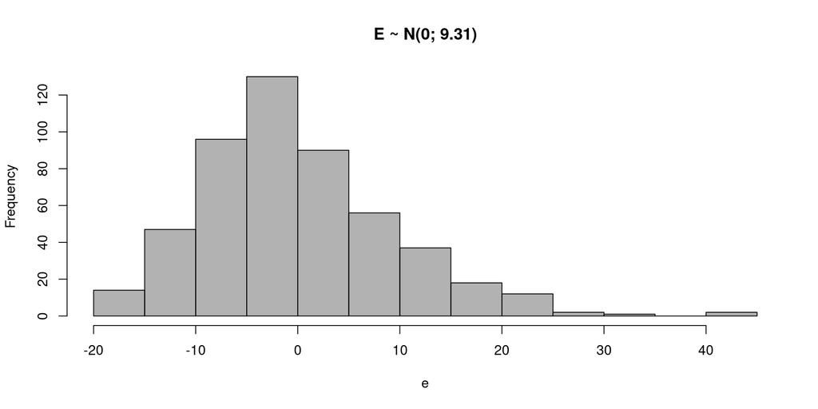

```r
e <- m$residuals
e_prumer <- round(mean(e), 2)
e_sd <- round(sd(e), 2)
hist(e,
     main = paste0("E ~ N(", e_prumer, "; ", e_sd, ")"),
     col = adjustcolor("black", alpha.f = 0.3))
```

```r
print(paste0("Teoretická směrodatná odchylka: ", round(s_e, 2)))
```

```
## [1] "Teoretická směrodatná odchylka: 9.32"
```

```r
print(paste0("Směrodatná odchylka chyb: ", e_sd))
```

```
## [1] "Směrodatná odchylka chyb: 9.31"
```

Bod 2. nejlépe ověříme pomocí grafu proměnné $X$ a $e$. Pokud tento graf odhalí závislost není chyba $e$ na $X$ nezávislá.

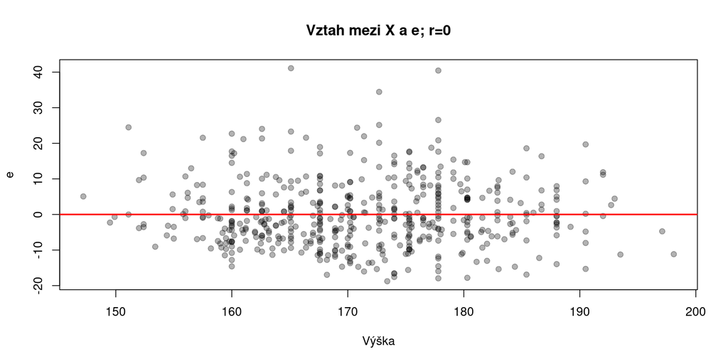

```r
r <- round(cor(d$vyska, e), 2)
plot(d$vyska, e,
     xlab = "Výška", main = paste0("Vztah mezi X a e; r=", r),
     pch = 19,
     col = adjustcolor("black", alpha.f = 0.3))
abline(lm(e ~ d$vyska), col = "red", lwd = 2)
```

3. Tento předpoklad můžeme ověřit z designu výzkumu, pomocí kterého jsme data sbírali. Tedy, zda jedna hodnota x závisí na jiné hodnotě x a stejně tak u y. Příkladem nezávislých pozorování x je například náhodný výběr jedinců z populace. Příkladem závislých pozorování je například časová řada pozorování, kde pozorování závisí na předchozích pozorováních.